# Week 7 homework Rmarkdown

Statistical Analysis

Week 7

# 1 Dataset 1 analysis

Read in dataset 1 from github

```r
dataset_1 <- vroom("https://raw.githubusercontent.com/eh17393/bioinformatics/main/Bioinformatics_data-master/Workshop%206/data%201.csv")
```

```r
dataset_1
```

```
## # A tibble: 150 x 5
##        y    x1    x2    x3    x4
##    <dbl> <dbl> <dbl> <dbl> <dbl>
##  1 0.732  1.27  1.61  1.67  1.96
##  2 0.773  1.37  1.56  1.09  1.44
##  3 0.230  1.57  1.33  1.49  1.37
##  4 0.411  1.91  1.45  1.46  1.17
##  5 0.264  1.20  1.50  1.38  1.05
##  6 0.270  1.90  1.18  1.99  1.66
##  7 0.457  1.94  1.53  1.18  1.58
##  8 0.409  1.66  1.08  1.81  1.99
##  9 0.333  1.63  1.28  1.07  1.60
## 10 0.481  1.06  1.21  1.40  1.06
## # ... with 140 more rows
```

## 1.1 Visualise dataset 1 with x1

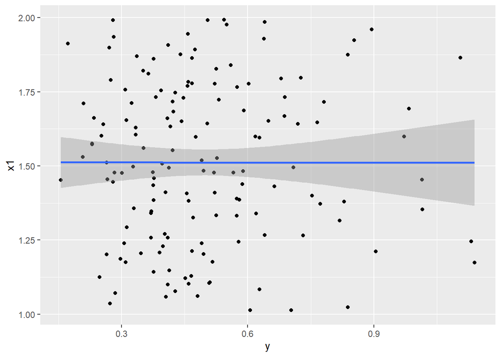

```r
ggplot(dataset_1, aes(x = y, y = x1)) +
  geom_point() +
  geom_smooth(method = "lm")
```

No significant correlation

## 1.2 Visualise dataset 1 with x2

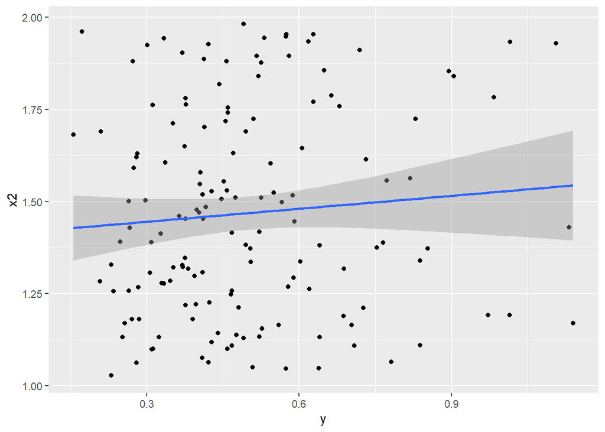

```r
ggplot(dataset_1, aes(x = y, y = x2)) +
  geom_point() +
  geom_smooth(method = "lm")
```

Potentially a significant positive correlation

Fit a glm with gaussian distribution and plot

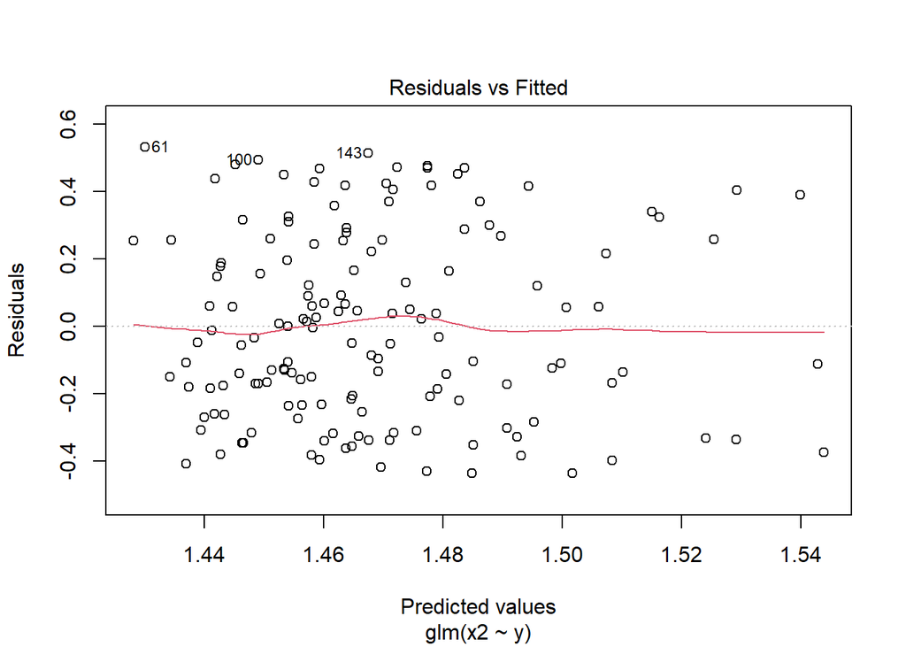

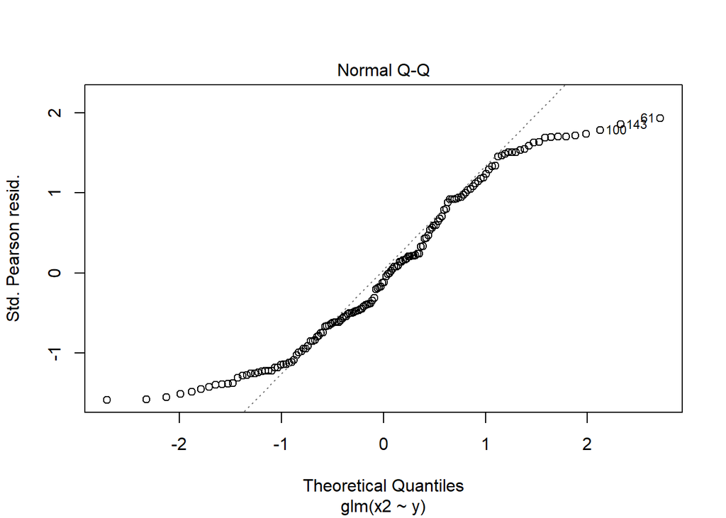

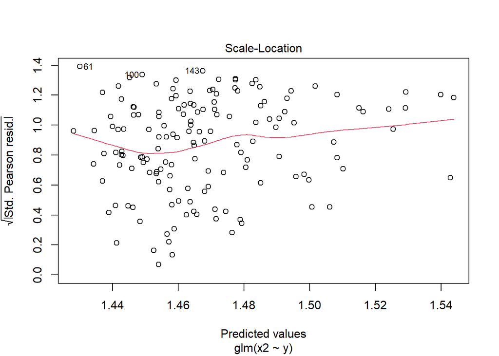

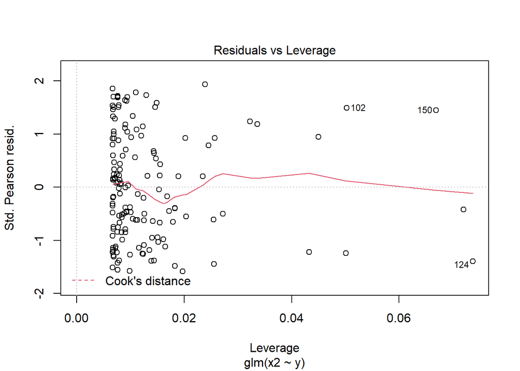

```r
mod1_d1x2 <- glm(x2 ~ y, data = dataset_1, family = "gaussian")
plot(mod1_d1x2)
```

Summarise mod 1

```r
summary(mod1_d1x2)
```

```
##
## Call:
## glm(formula = x2 ~ y, family = "gaussian", data = dataset_1)
##
## Deviance Residuals:
##      Min        1Q    Median        3Q       Max
## -0.43722  -0.22998  -0.03413   0.25429   0.53133
##
## Coefficients:
##             Estimate Std. Error t value Pr(>|t|)
## (Intercept)  1.40989    0.06021  23.418   <2e-16 ***
## y            0.11745    0.11205   1.048    0.296
## ---
## Signif. codes:  0 '***' 0.001 '**' 0.01 '*' 0.05 '.' 0.1 ' ' 1
##
## (Dispersion parameter for gaussian family taken to be 0.07732483)
##
##     Null deviance: 11.529  on 149  degrees of freedom
## Residual deviance: 11.444  on 148  degrees of freedom
## AIC: 45.707
##
## Number of Fisher Scoring iterations: 2
```

Significant intercept however plots are not perfect therefore test with other models with gaussian distribution

Fit a glm with a gaussian distribution with a log link

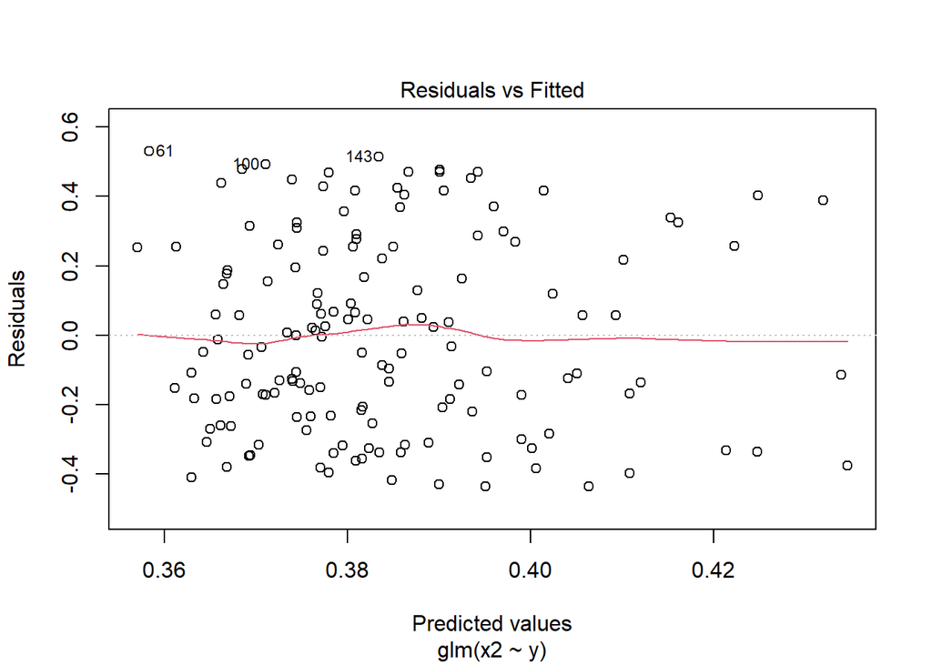

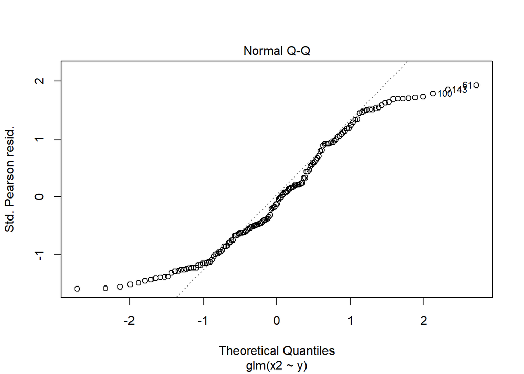

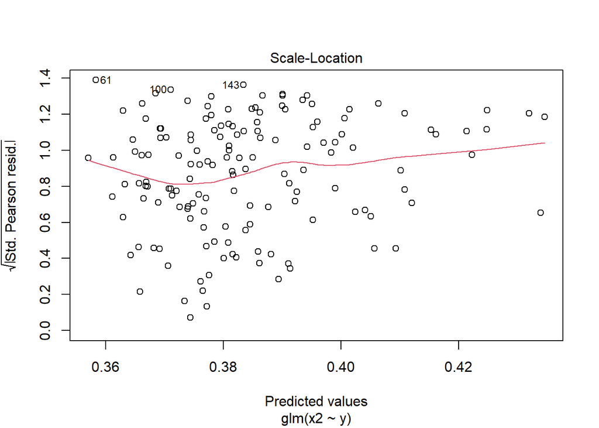

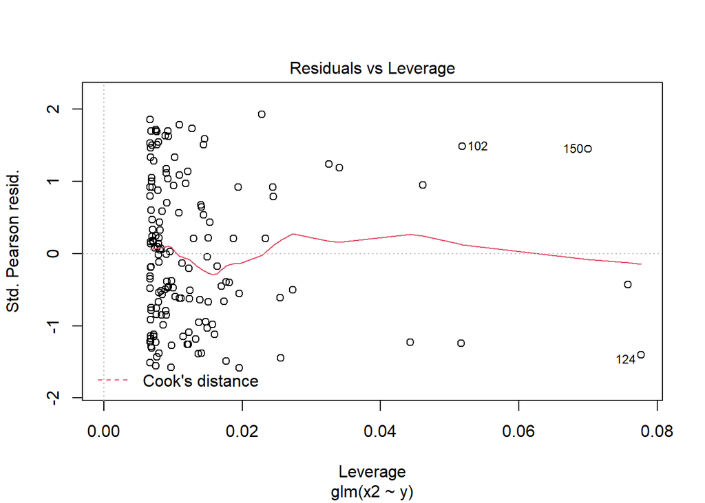

```r
mod2_d1x2 <- glm(x2 ~ y,
                   data = dataset_1,
                   family = gaussian(link = "log"))
plot(mod2_d1x2)
```

Fit glm with a guassian model with an inverse link

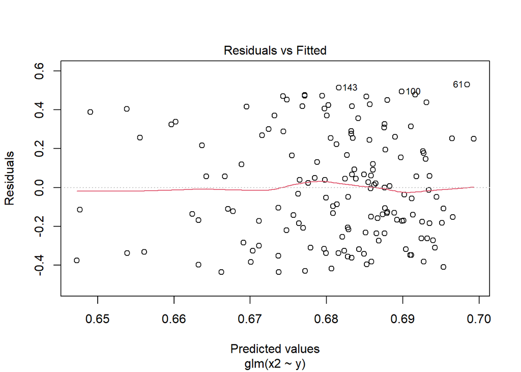

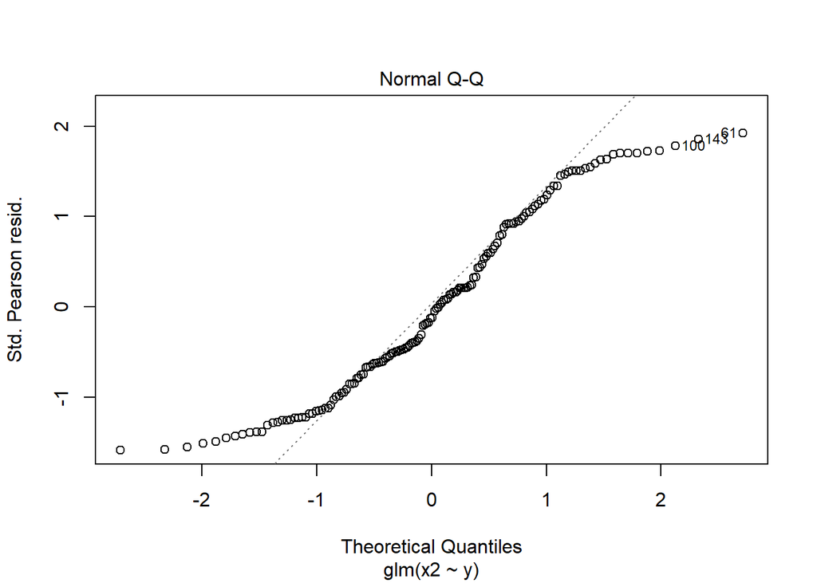

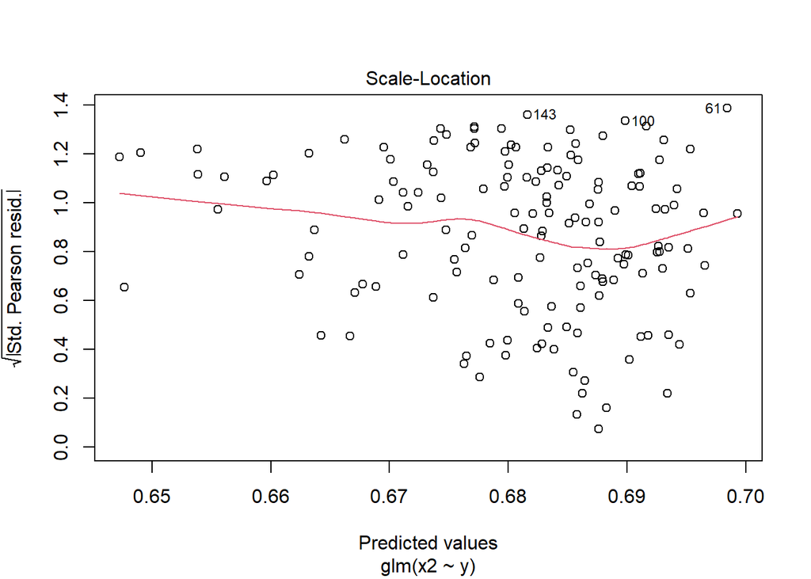

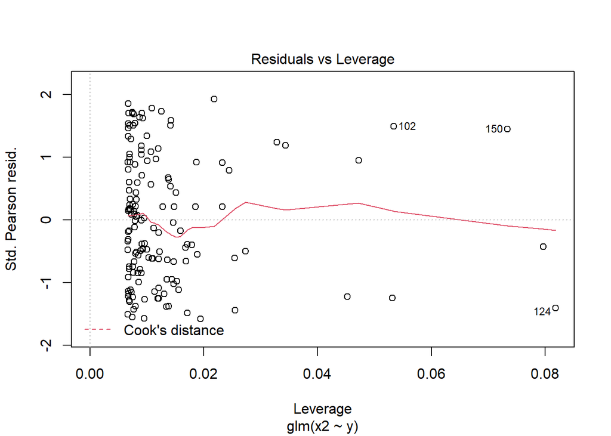

```r
mod3_d1x2 <- glm(x2 ~ y,
                   data = dataset_1,
                   family = gaussian(link = "inverse"))
plot(mod3_d1x2)
```

Compare models with AIC and rank

```r
library(gamlr)
##compare the models
AIC_mods <- data.frame(model = c("mod1_d1x2", "mod2_d1x2", "mod3_d1x2"),
                       AICc = c(AICc(mod1_d1x2), AICc(mod2_d1x2), AICc(mod3_d1x2)))

##rank the models
AIC_mods[order(AIC_mods$AICc),]
```

```
##       model     AICc
## 1 mod1_d1x2 45.87146
## 2 mod2_d1x2 45.87859
## 3 mod3_d1x2 45.88609
```

## 1.3 Visualise dataset 1 with x3

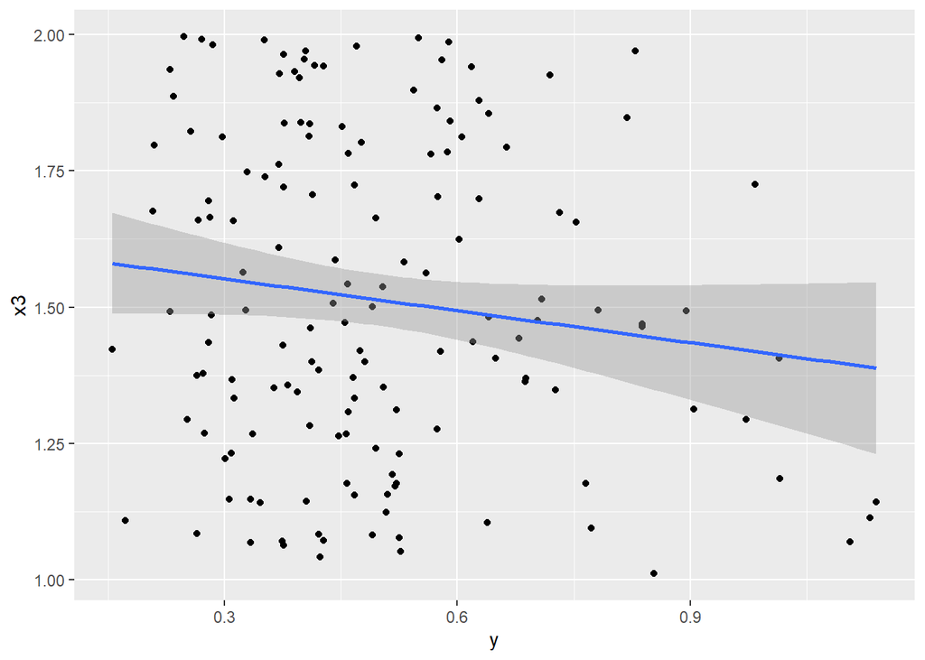

```r
ggplot(dataset_1, aes(x = y, y = x3)) +
  geom_point() +
  geom_smooth(method = "lm")
```

Potentially a significant correlation with y

Fit a glm with gaussian distribution and plot

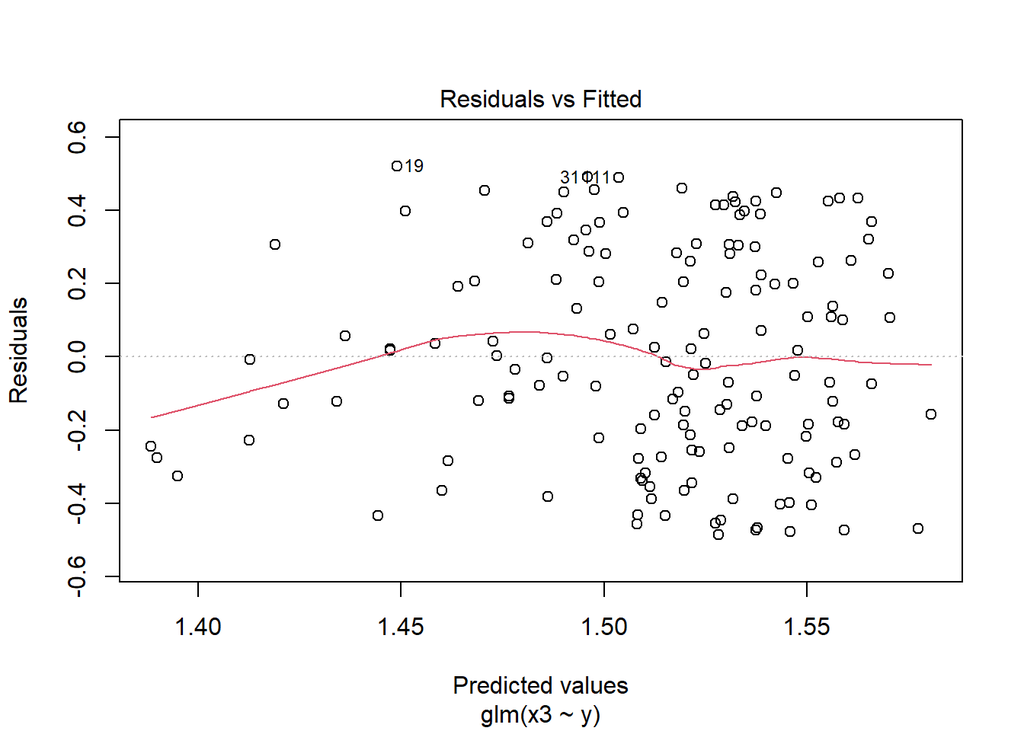

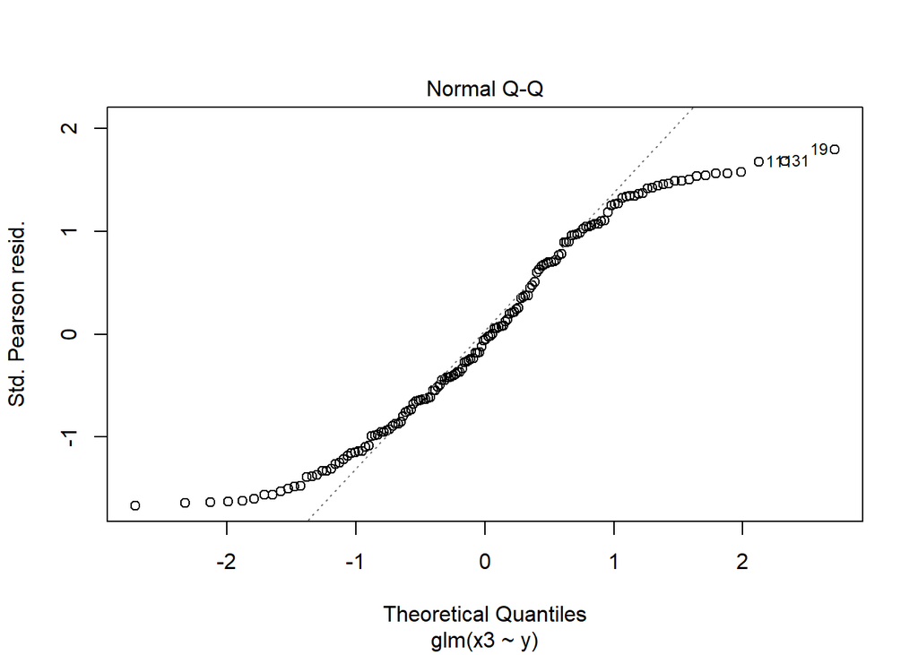

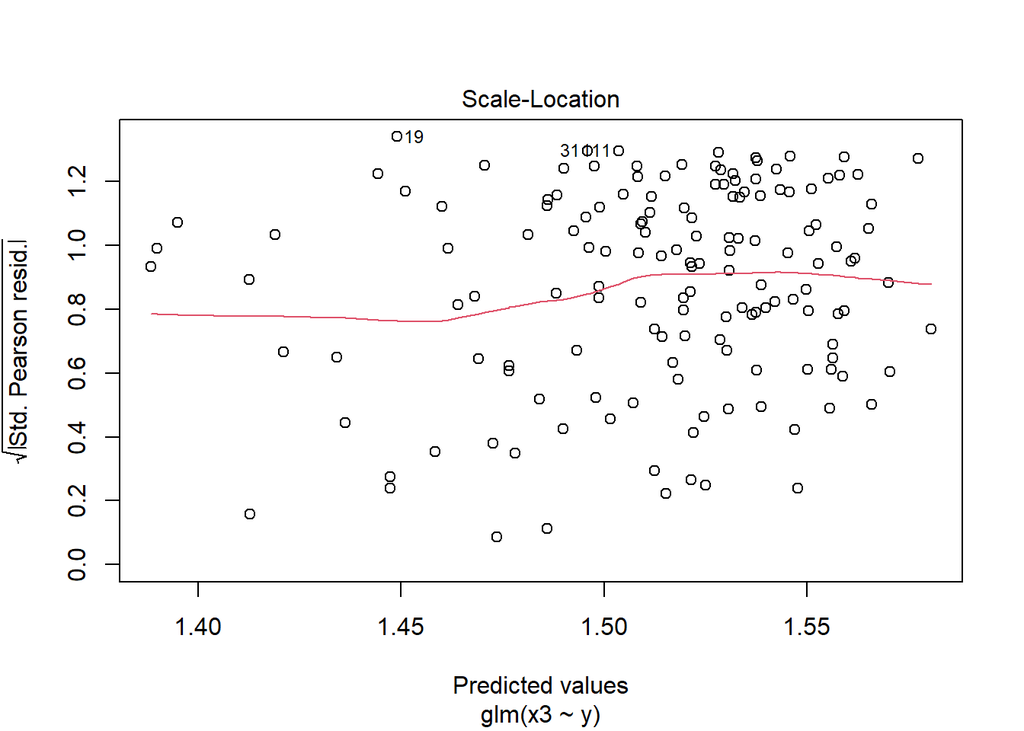

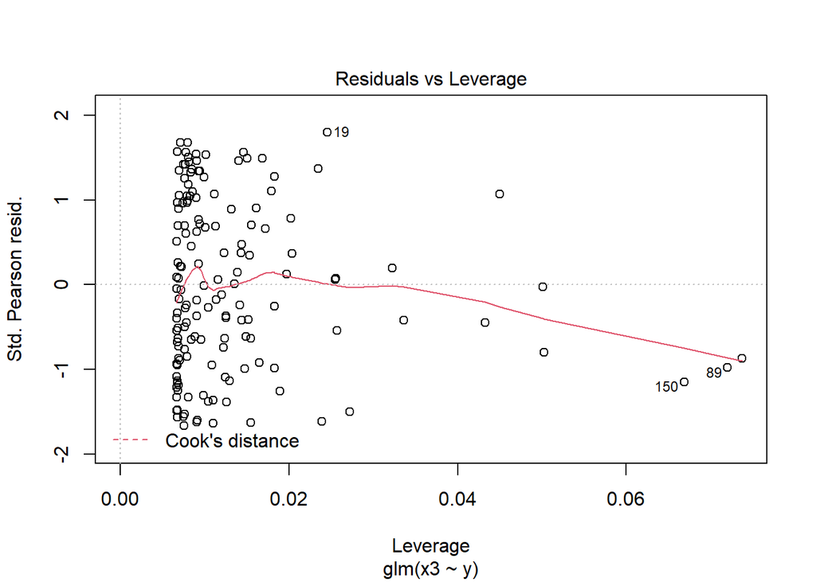

```r
mod1_d1x3 <- glm(x3 ~ y, data = dataset_1, family = "gaussian")
plot(mod1_d1x3)
```

Summarise mod 1

```r
summary(mod1_d1x3)
```

```
##
## Call:
## glm(formula = x3 ~ y, family = "gaussian", data = dataset_1)
##
## Deviance Residuals:
##      Min        1Q    Median        3Q       Max
## -0.48673  -0.24732  -0.01613   0.27591   0.52019
##
## Coefficients:
##             Estimate Std. Error t value Pr(>|t|)
## (Intercept)  1.61084    0.06342  25.399   <2e-16 ***
## y           -0.19507    0.11804  -1.653    0.101
## ---
## Signif. codes:  0 '***' 0.001 '**' 0.01 '*' 0.05 '.' 0.1 ' ' 1
##
## (Dispersion parameter for gaussian family taken to be 0.08580535)
##
##     Null deviance: 12.934  on 149  degrees of freedom
## Residual deviance: 12.699  on 148  degrees of freedom
## AIC: 61.317
##
## Number of Fisher Scoring iterations: 2
```

## 1.4 Visualise dataset 1 with x4

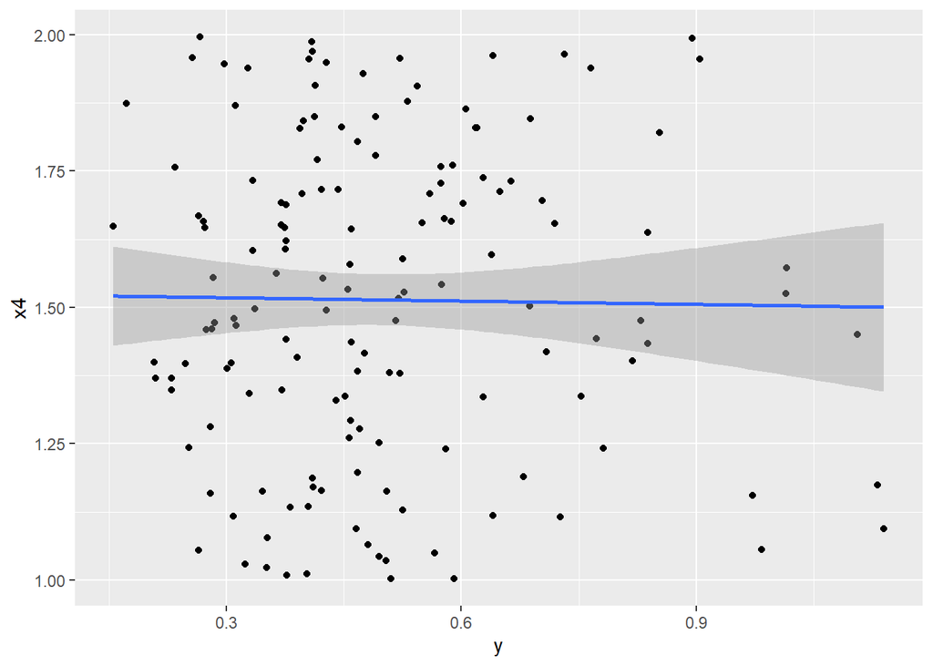

```r
ggplot(dataset_1, aes(x = y, y = x4)) +
  geom_point() +
  geom_smooth(method = "lm")
```

No significant correlation

# 2 Dataset 2 analysis

Read in dataset 2 from github

```r
dataset_2 <- vroom("https://raw.githubusercontent.com/eh17393/bioinformatics/main/Bioinformatics_data-master/Workshop%206/data%202.csv")
```

```r
dataset_2
```

```
## # A tibble: 50 x 4
##         y    x1    x2    x3
##     <dbl> <dbl> <dbl> <dbl>
##  1 0.0363  1.05  1.69  1.84
##  2 0.102   1.53  1.25  1.08
##  3 0.123   1.44  1.41  1.72
##  4 0.123   1.91  1.12  1.86
##  5 0.0773  1.88  1.13  1.98
##  6 0.105   1.16  1.64  1.25
##  7 0.0399  1.75  1.35  1.02
##  8 0.232   1.40  1.42  1.22
##  9 0.0725  1.56  1.94  1.12
## 10 0.0757  1.08  1.38  1.39
## # ... with 40 more rows
```

## 2.1 Visualise dataset_2 with x1

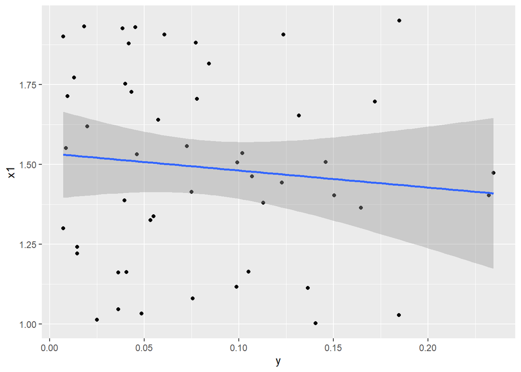

```r
ggplot(dataset_2, aes(x = y, y = x1)) +
  geom_point() +
  geom_smooth(method = "lm")
```

Fit a glm with gaussian distribution and plot

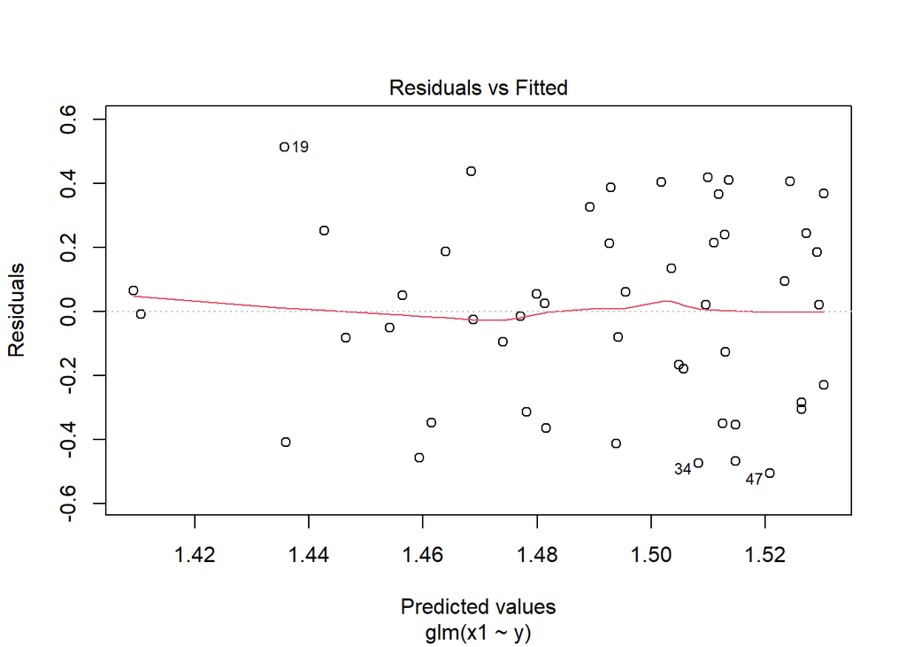

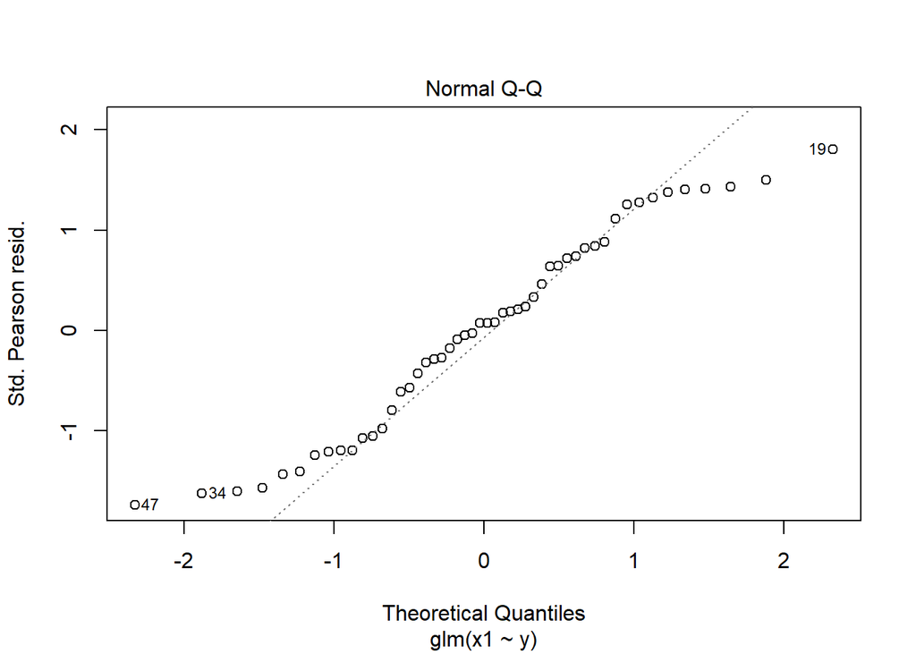

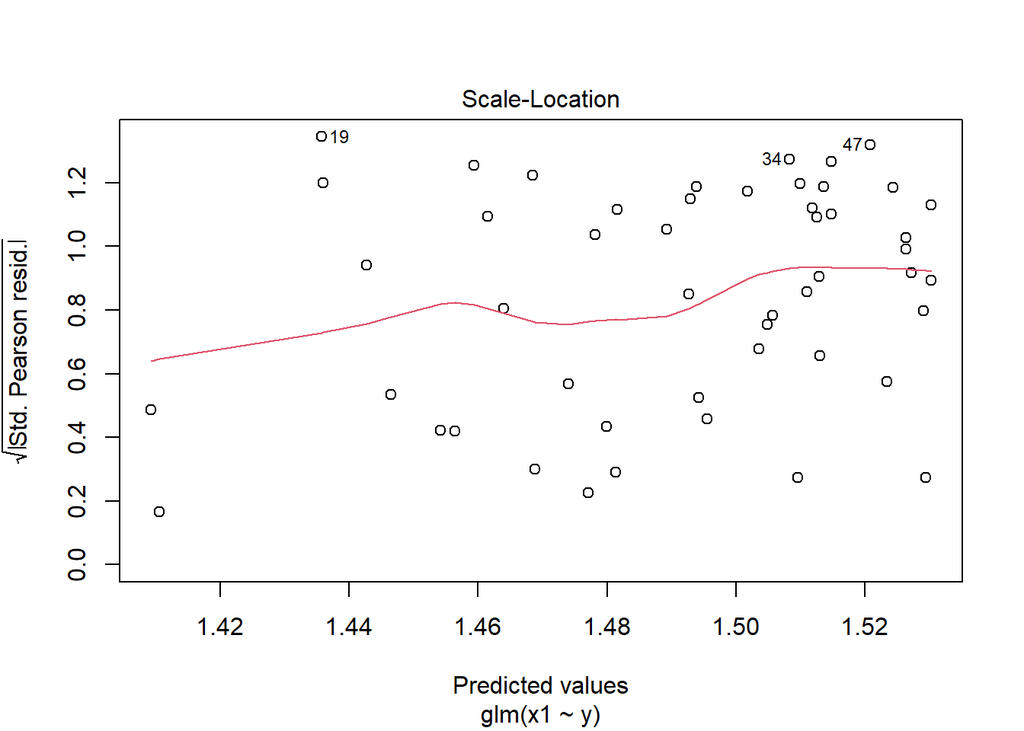

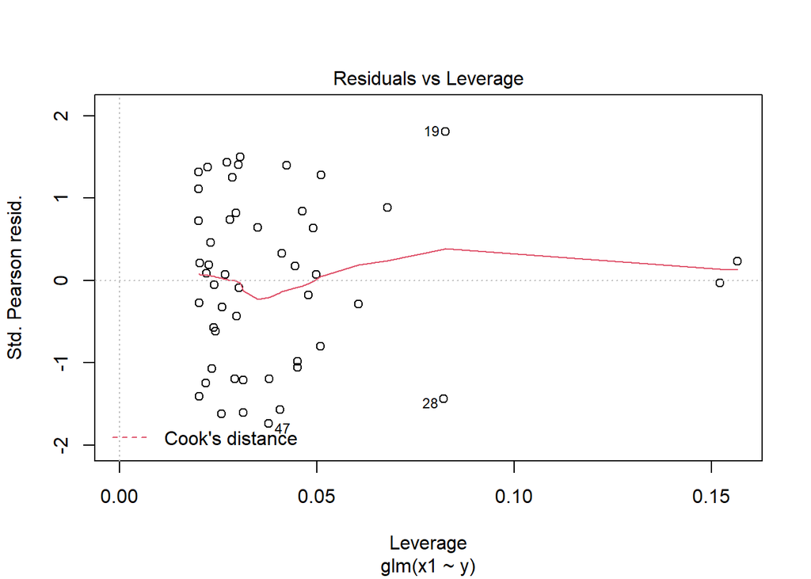

```r
mod1_d2x1 <- glm(x1 ~ y, data = dataset_2, family = "gaussian")
plot(mod1_d2x1)
```

Normal Q-Q plot doesn’t fit very well therefore try with other glms

Fit glm with poisson distribution

```r
mod2_d2x1 <- glm(x1 ~ y, data = dataset_2, family = "poisson")
```

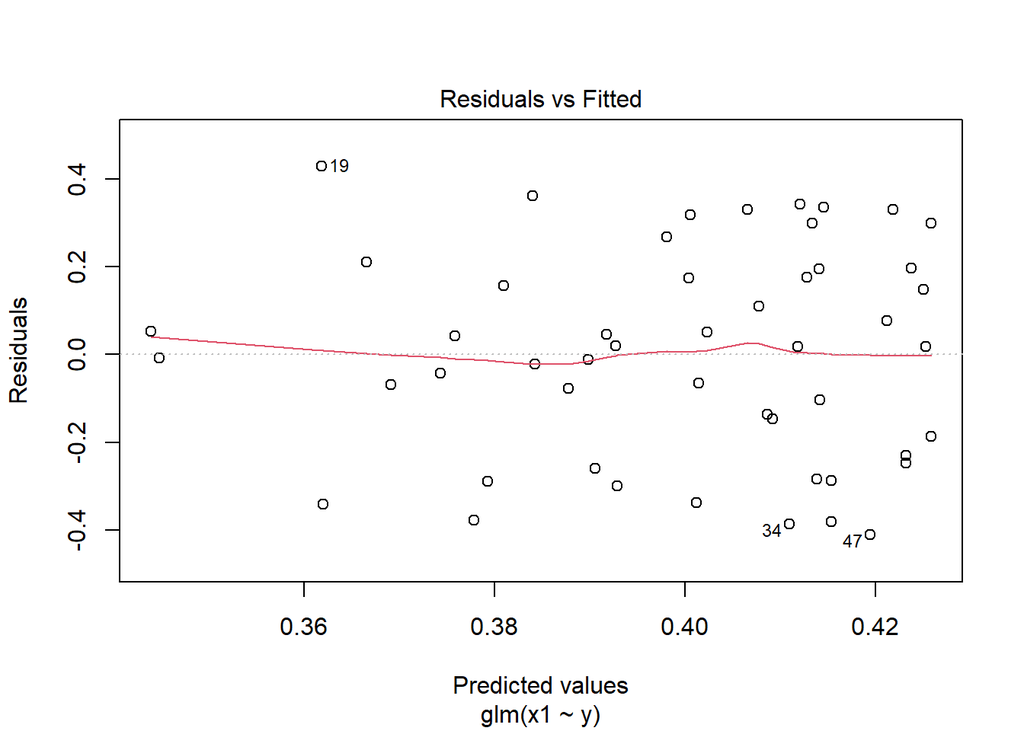

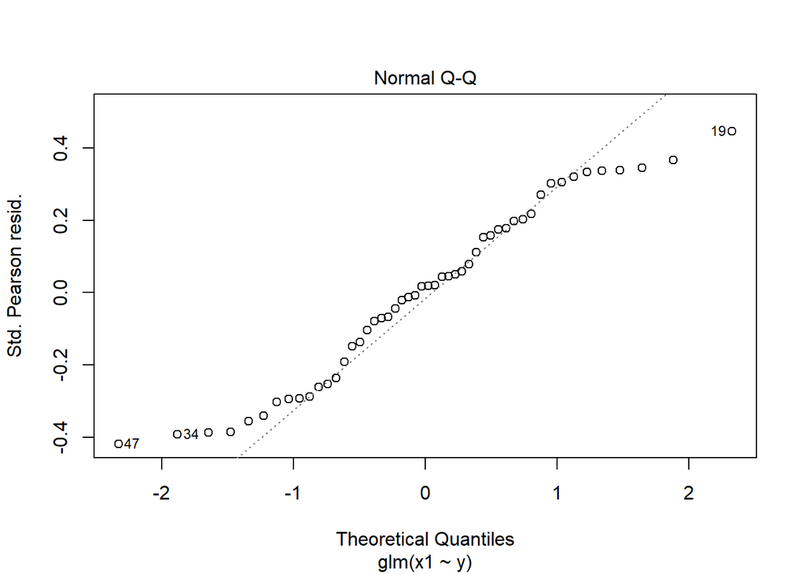

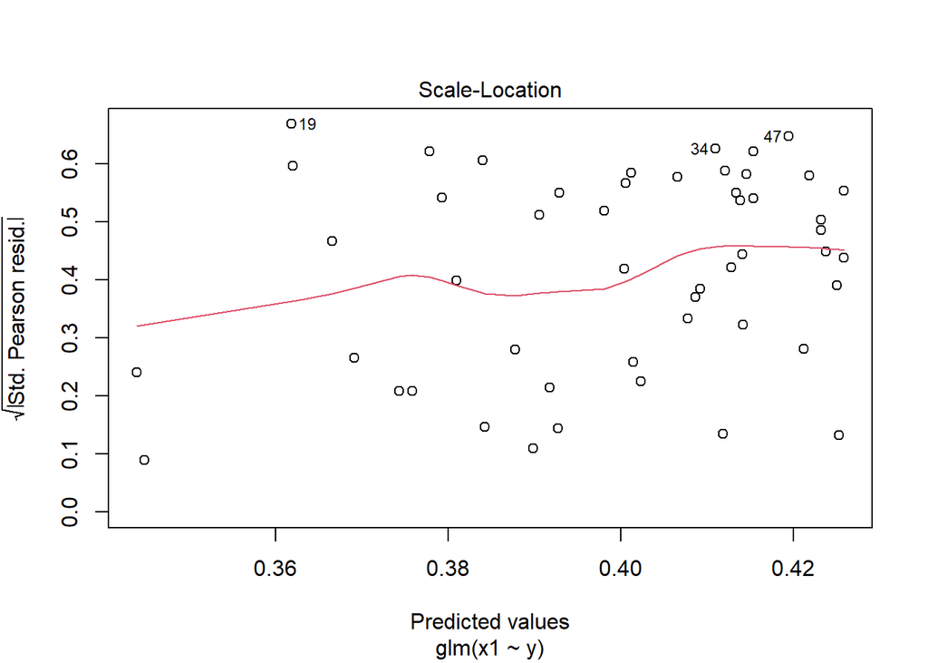

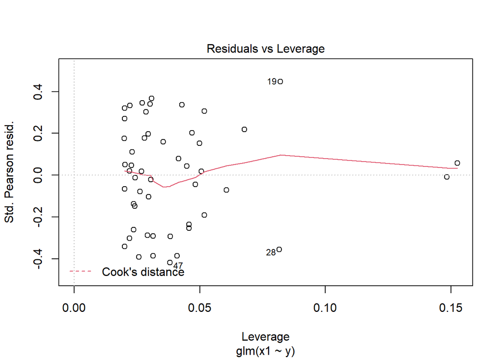

```r
plot(mod2_d2x1)
```

Fit a glm with a gaussian distribution with a log link and plot

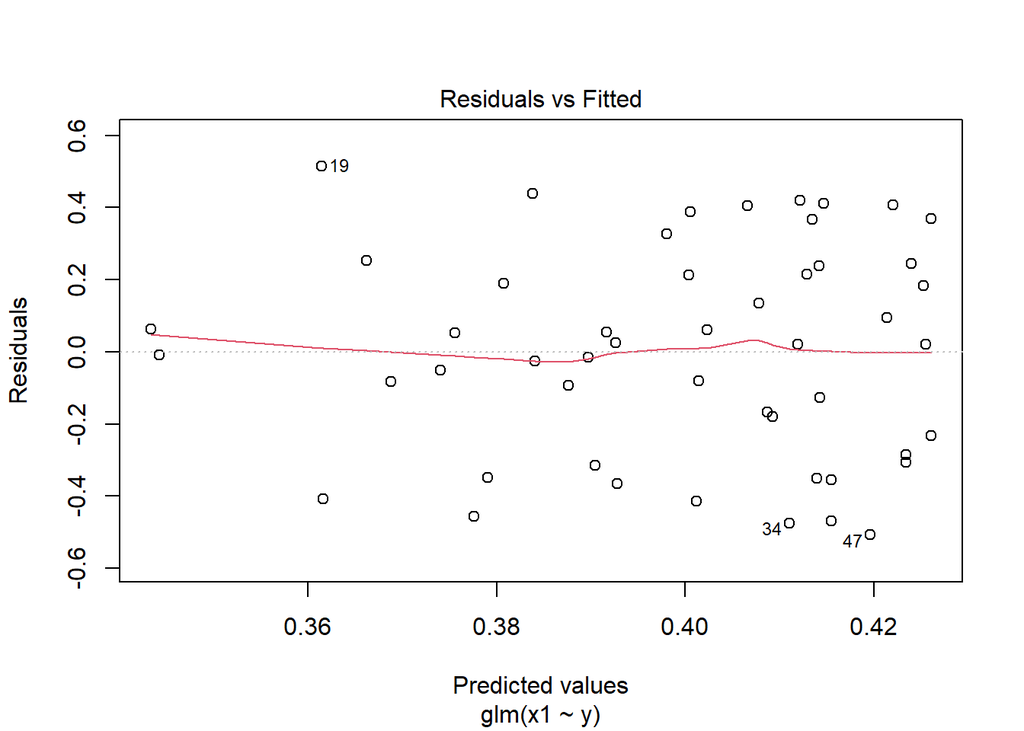

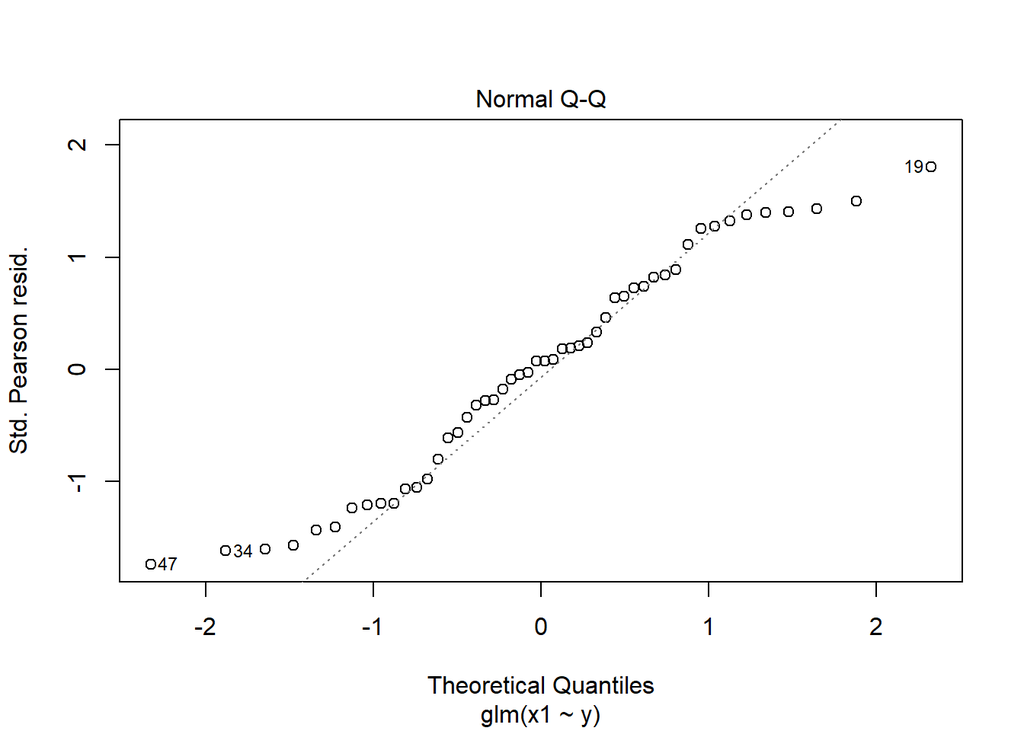

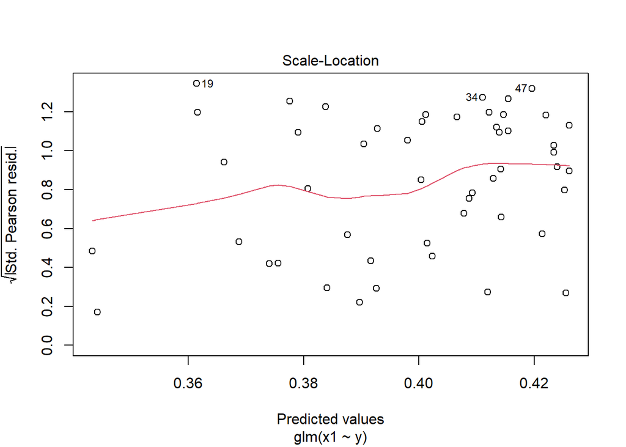

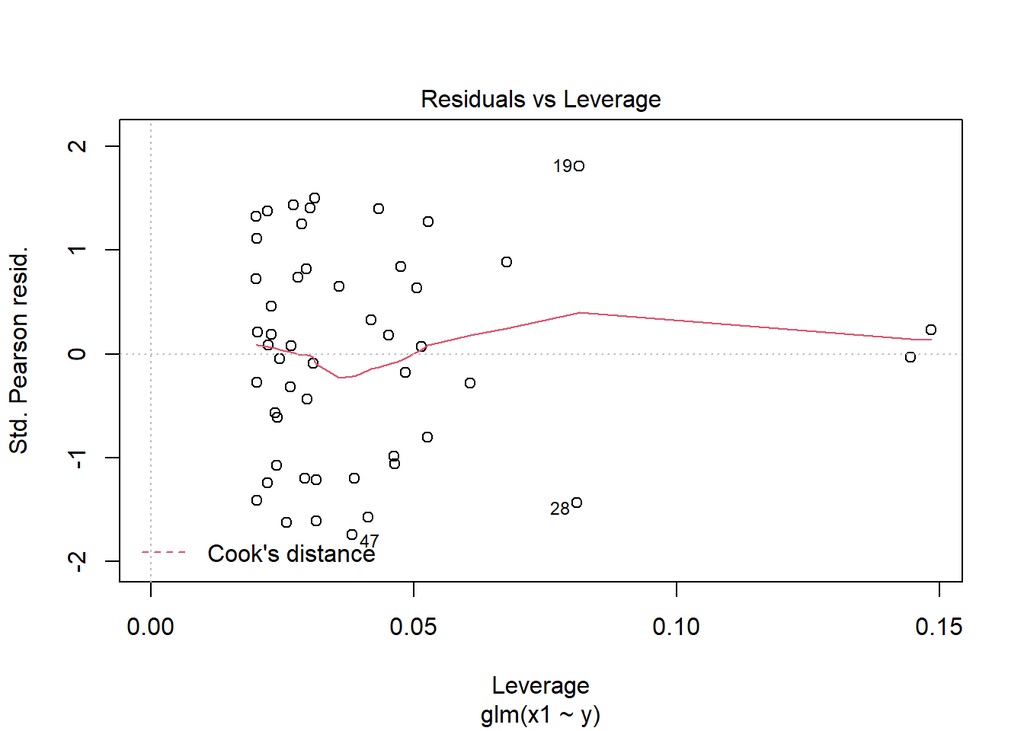

```r
mod3_d2x1 <- glm(x1 ~ y,
               data = dataset_2,
               family = gaussian(link = "log"))
plot(mod3_d2x1)
```

Fit glm with a guassian model with an inverse link

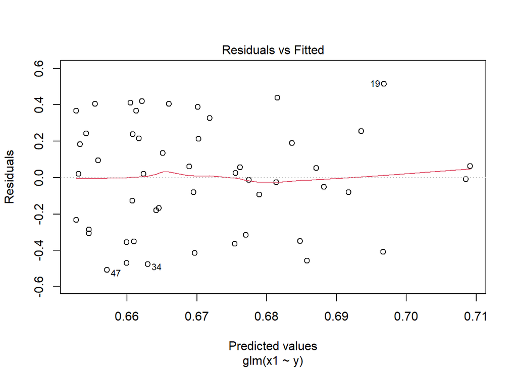

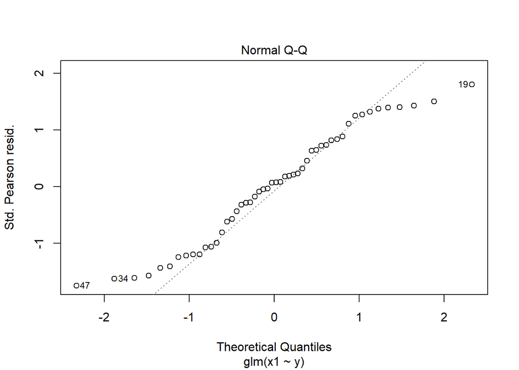

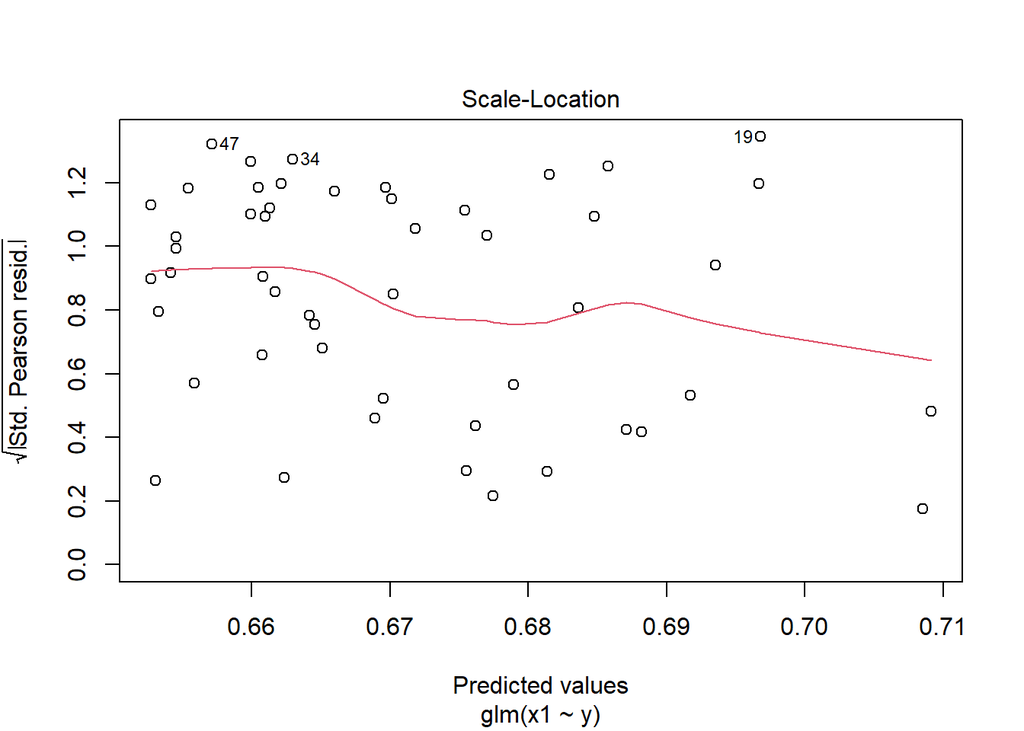

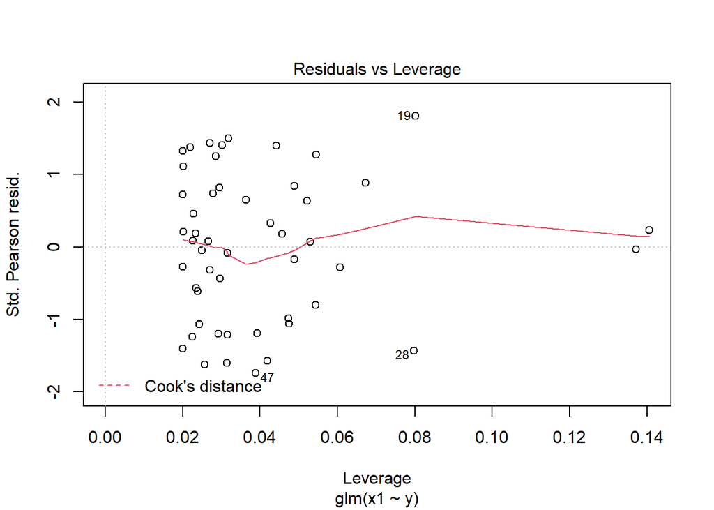

```r
mod4_d2x1 <- glm(x1 ~ y,
               data = dataset_2,
               family = gaussian(link = "inverse"))
plot(mod4_d2x1)
```

Compare and rank models with AIC

```r
##compare the models
AIC_modsd2 <- data.frame(model = c("mod1_d2x1", "mod2_d2x1", "mod3_d2x1", "mod4_d2x1"),
                       AICc = c(AICc(mod1_d2x1), AICc(mod2_d2x1), AICc(mod3_d2x1), AICc(mod4_d2x1)))

##rank the models
AIC_modsd2[order(AIC_mods$AICc),]
```

```
##       model     AICc
## 1 mod1_d2x1 24.86779
## 2 mod2_d2x1      Inf
## 3 mod3_d2x1 24.86214
```

## 2.2 Visualise dataset_2 with x2

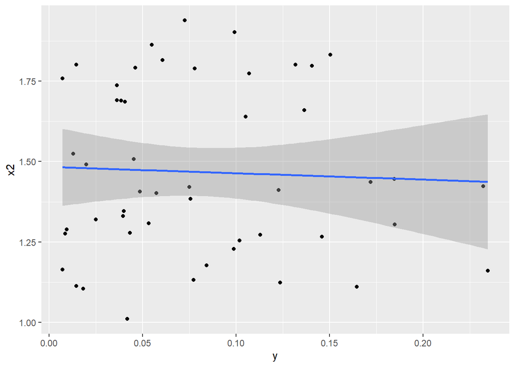

```r
ggplot(dataset_2, aes(x = y, y = x2)) +
  geom_point() +
  geom_smooth(method = "lm")
```

## 2.3 Visualise dataset_2 with x3

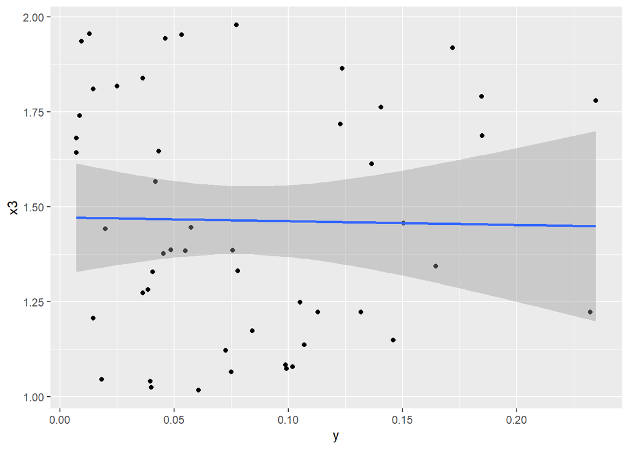

```r
ggplot(dataset_2, aes(x = y, y = x3)) +
  geom_point() +
  geom_smooth(method = "lm")
```

# 3 Dataset 4 analysis

Read in dataset 4 from github

```r
dataset_4 <- vroom("https://raw.githubusercontent.com/eh17393/bioinformatics/main/Bioinformatics_data-master/Workshop%206/data%204.csv")
```

```r
dataset_4
```

```
## # A tibble: 170 x 4
##        y    x1    x2    x3
##    <dbl> <dbl> <dbl> <dbl>
##  1    35  1.44  1.71  1.57
##  2    16  1.76  1.08  1.56
##  3    38  1.71  1.61  1.43
##  4    26  1.17  1.49  1.96
##  5    20  1.87  1.27  1.71
##  6    10  1.09  1.29  1.26
##  7    13  1.16  1.48  1.93
##  8    50  1.85  1.96  1.42
##  9    24  1.63  1.42  1.82
## 10    20  1.21  1.84  1.75
## # ... with 160 more rows
```

## 3.1 Visualise dataset 4 with x1

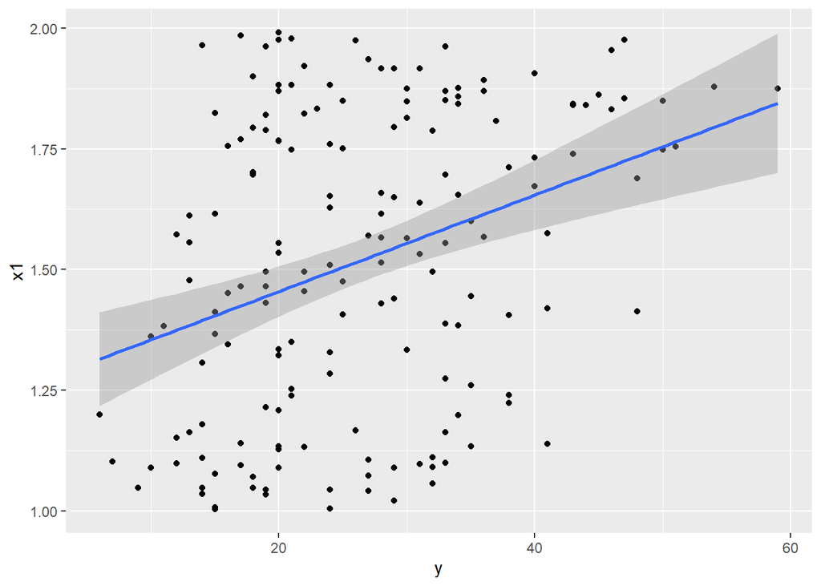

```r
ggplot(dataset_4, aes(x = y, y = x1)) +
  geom_point() +
  geom_smooth(method = "lm")
```

Shows a potentially strong positive correlation with y

Fit a glm with gaussian distribution, plot and summarise

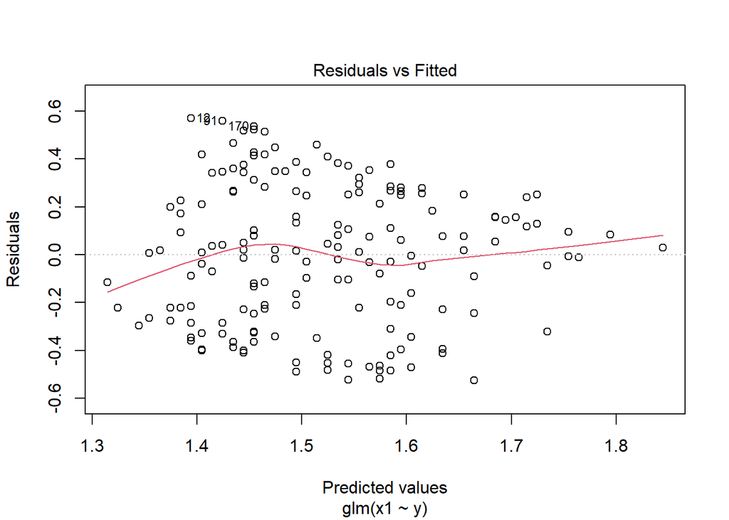

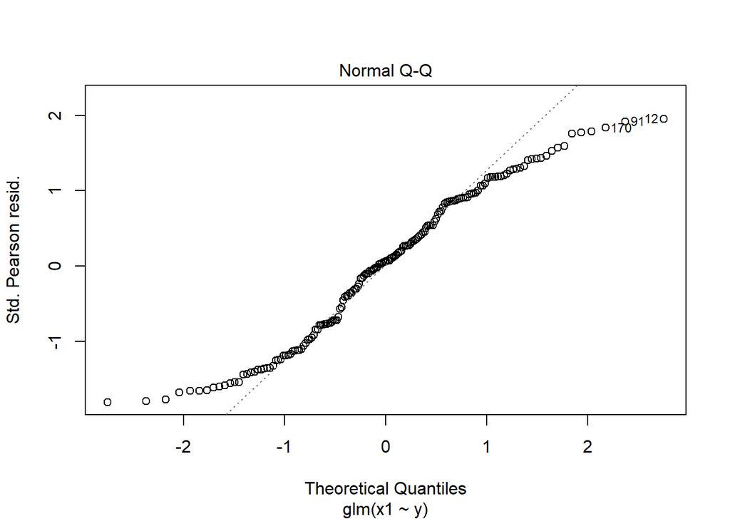

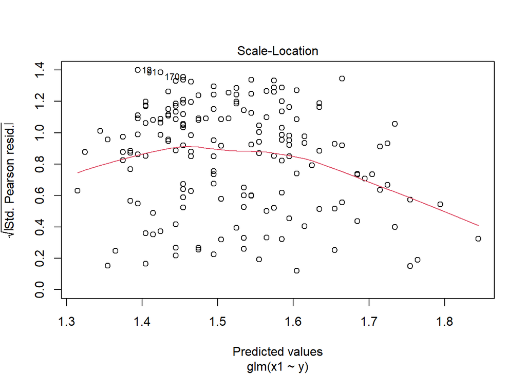

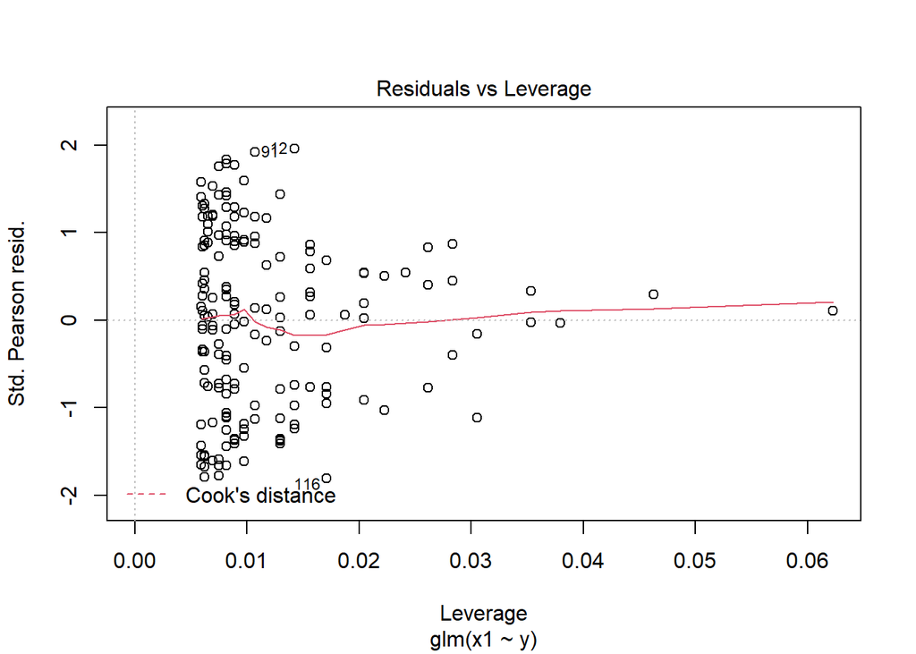

```r
mod1_d4x1 <- glm(x1 ~ y, data = dataset_4, family = "gaussian")
plot(mod1_d4x1)
```

```r
summary(mod1_d4x1)
```

```
##
## Call:
## glm(formula = x1 ~ y, family = "gaussian", data = dataset_4)
##
## Deviance Residuals:
##      Min        1Q    Median        3Q       Max
## -0.52600  -0.24128   0.01809   0.25128   0.56961
##
## Coefficients:
##             Estimate Std. Error t value Pr(>|t|)
## (Intercept) 1.254629   0.061019   20.56  < 2e-16 ***
## y           0.009998   0.002141    4.67 6.13e-06 ***
## ---
## Signif. codes:  0 '***' 0.001 '**' 0.01 '*' 0.05 '.' 0.1 ' ' 1
##
## (Dispersion parameter for gaussian family taken to be 0.08586492)
##
##     Null deviance: 16.298  on 169  degrees of freedom
## Residual deviance: 14.425  on 168  degrees of freedom
## AIC: 69.081
##
## Number of Fisher Scoring iterations: 2
```

Fit glm with poisson distribution, plot and summarise

```r
mod2_d4x1 <- glm(x1 ~ y, data = dataset_4, family = "poisson")
```

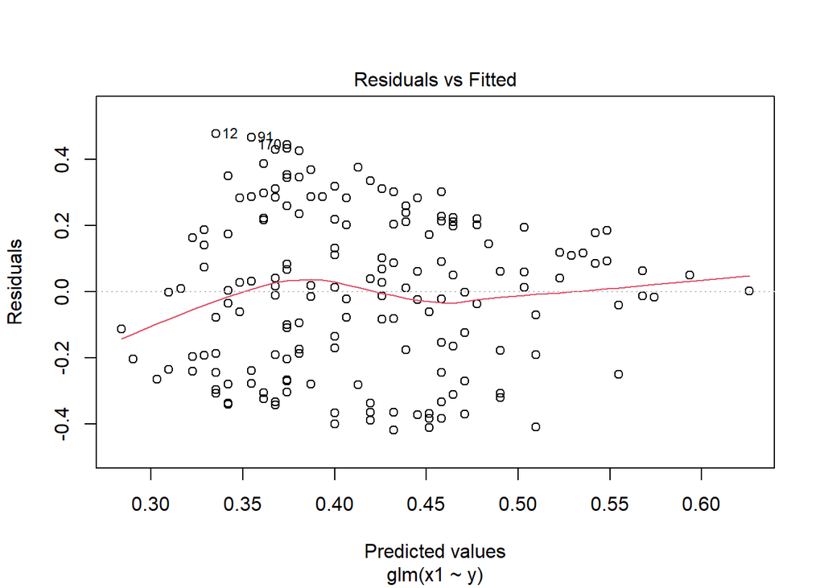

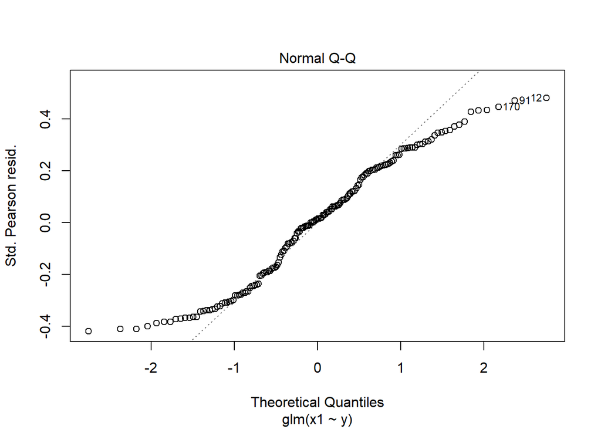

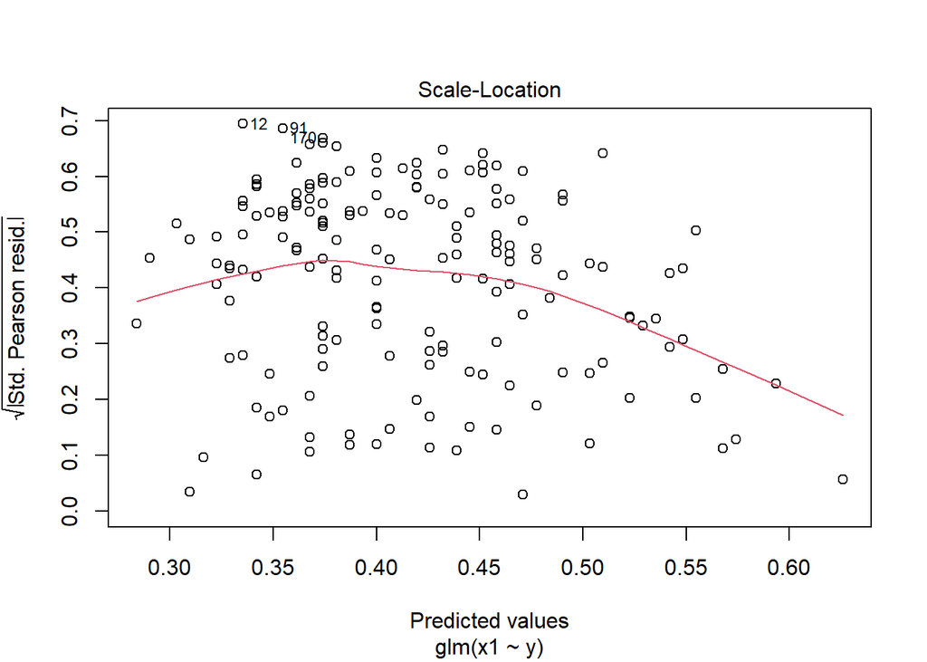

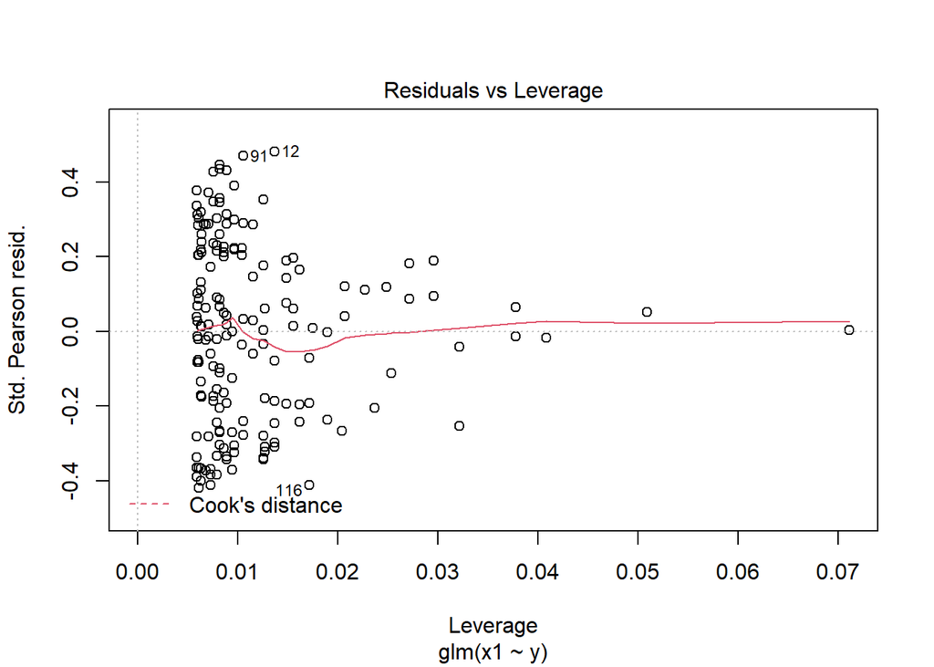

```r
plot(mod2_d4x1)
```

The residuals vs leverage graph is better than gaussian

```r
summary(mod2_d4x1)
```

```
##
## Call:
## glm(formula = x1 ~ y, family = "poisson", data = dataset_4)
##
## Deviance Residuals:
##     Min       1Q   Median       3Q      Max
## -0.4464  -0.2072   0.0131   0.1979   0.4506
##
## Coefficients:
##             Estimate Std. Error z value Pr(>|z|)
## (Intercept) 0.245028   0.170139    1.44    0.150
## y           0.006456   0.005816    1.11    0.267
##
## (Dispersion parameter for poisson family taken to be 1)
##
##     Null deviance: 10.9767  on 169  degrees of freedom
## Residual deviance:  9.7598  on 168  degrees of freedom
## AIC: Inf
##
## Number of Fisher Scoring iterations: 4
```

Not significant therefore log x1 and summarise

```r
mod2log_d4x1 <- glm(log10(x1) ~ y, data = dataset_4, family = "poisson")
summary(mod2log_d4x1)
```

```
##
## Call:
## glm(formula = log10(x1) ~ y, family = "poisson", data = dataset_4)
##
## Deviance Residuals:
##     Min       1Q   Median       3Q      Max
## -0.5507  -0.2077   0.0263   0.1691   0.3635
##
## Coefficients:
##             Estimate Std. Error z value Pr(>|z|)
## (Intercept) -2.21482    0.51254  -4.321 1.55e-05 ***
## y            0.01660    0.01682   0.987    0.324
## ---
## Signif. codes:  0 '***' 0.001 '**' 0.01 '*' 0.05 '.' 0.1 ' ' 1
##
## (Dispersion parameter for poisson family taken to be 1)
##
##     Null deviance: 10.3800  on 169  degrees of freedom
## Residual deviance:  9.4341  on 168  degrees of freedom
## AIC: Inf
##
## Number of Fisher Scoring iterations: 5
```

## 3.2 Visualise dataset_4 with x2

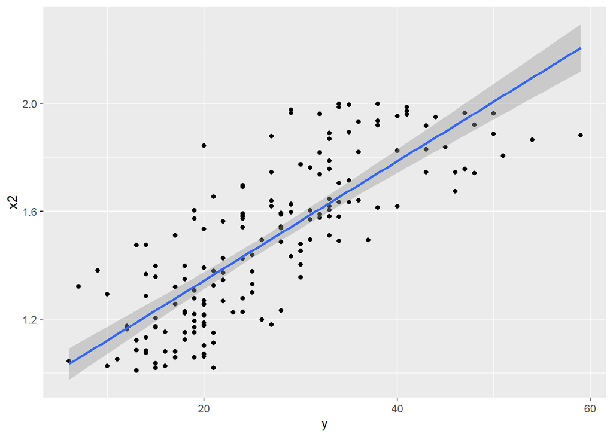

```r
ggplot(dataset_4, aes(x = y, y = x2)) +
  geom_point() +
  geom_smooth(method = "lm")
```

A clear positive correlation with y

Fit glm with log link and poisson distribution and summarise

```r
mod2log_d4x2 <- glm(log10(x2) ~ y, data = dataset_4, family = "poisson")
summary(mod2log_d4x2)
```

```
##
## Call:
## glm(formula = log10(x2) ~ y, family = "poisson", data = dataset_4)
##
## Deviance Residuals:
##      Min        1Q    Median        3Q       Max
## -0.43319  -0.12241   0.00016   0.10640   0.36184
##
## Coefficients:
##             Estimate Std. Error z value Pr(>|z|)
## (Intercept) -2.84052    0.54488  -5.213 1.86e-07 ***
## y            0.03605    0.01655   2.178   0.0294 *
## ---
## Signif. codes:  0 '***' 0.001 '**' 0.01 '*' 0.05 '.' 0.1 ' ' 1
##
## (Dispersion parameter for poisson family taken to be 1)
##
##     Null deviance: 8.9938  on 169  degrees of freedom
## Residual deviance: 4.4770  on 168  degrees of freedom
## AIC: Inf
##
## Number of Fisher Scoring iterations: 5
```

x2 is significant with poisson error distribution and log link function

## 3.3 Visualise dataset_4 with x3

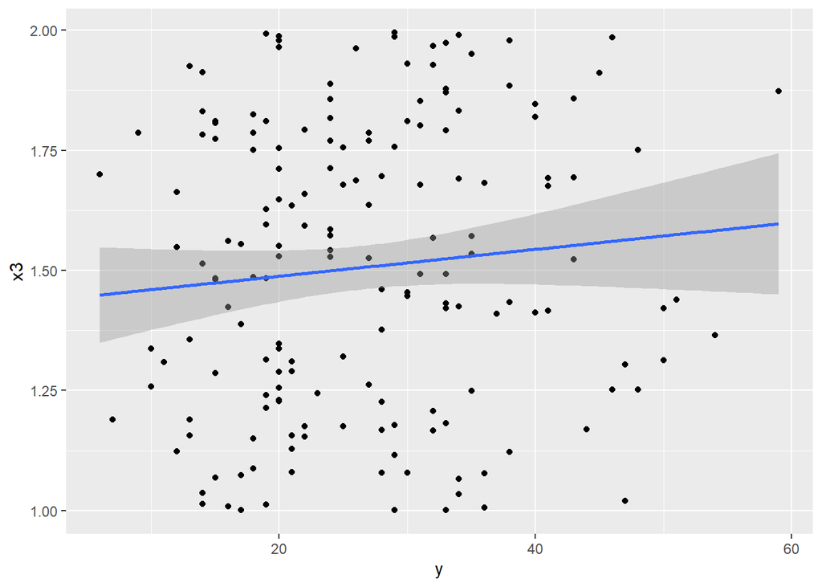

```r
ggplot(dataset_4, aes(x = y, y = x3)) +
  geom_point() +
  geom_smooth(method = "lm")
```

No clear correlation